# Analysis of Length of Growing Season

# Load Libraries

```r
library(tidyverse)
library(readr)
```

# Set Graphic Defaults

This code block calls a script that establishes defaults for a consistent Casco Bay State of the Bay graphics look and feel. It establishes cbep_colors, cbep_colors2, and theme_cbep, after loading selected fonts. IF you do not run this code, you will need to define those names somewhere else, or remove references to them in the remainder of the code.

```r
sibfldnm <- 'Graphics'
parent <- dirname(getwd())
sibling <- paste(parent,sibfldnm, sep = '/')
fn <- 'CBEPGraphicsSetup.R'
source(paste(sibling,fn, sep = '/'))
```

```
Registering fonts with R
```

```
[1] "Colors..."
[1] "Fonts..."
```

[output not shown]

```
[1] "Geom Defaults..."
```

# Read Data

The frost-free period needs to be derived directly from the daily temperature data. Note that temperature in the source data is in tenths of a degree C.

```r
sibfldnm <- 'Original Data'
parent <- dirname(getwd())
sibling <- paste(parent,sibfldnm, sep = '/')
fn <- 'longdailydata.csv'
longdailydata <- read_csv(paste(sibling,fn, sep = '/')) %>%
  select(-station) %>%
  filter(datatype %in% c('TMAX', 'TMIN')) %>%
  mutate(doy =  as.numeric(format(date, format='%j'))) %>%
  mutate(month = as.numeric(format(date, format='%m'))) %>%
  mutate(year = as.numeric(format(date, format='%Y'))) %>%
  mutate(cyear = year-1980)
```

# Find First and Last Frost Dates

The following strategy was suggested by a Stack Overflow answer here:  
https://stackoverflow.com/questions/41328946/find-last-values-by-condition

In brief, we filter a dataframe down to data that meets our criteria – here, days with temperatures below freezing – and then group_by() to isolate data from each year, and finally slice() to pick the first or last item in the list. Be aware that this strategy depends on the data being in chronological order.

```r
cutoffinF <- 32
cutoffinC <- (cutoffinF − 32) * 5/9
firstfrosts <- longdailydata %>%
  spread(key = datatype, value = value) %>%
  filter(year>1940) %>%                 # 1940 is an incomplete year in the daily data
  mutate(TMIN = TMIN/10) %>%            # raw data is in tenths of degree C
  filter(TMIN<= cutoffinC) %>%          # Only days below freezing
  filter(month>=7) %>%                  # only the last half of the year
  group_by(year) %>%
  slice(1)  %>%                         # Choose the first record
  select(date, year, doy)
lastfrosts <- longdailydata %>%
  spread(key = datatype, value = value) %>%
  filter(year>1940) %>%                 # 1940 is an incomplete year in the daily data
  filter(TMIN<= cutoffinC) %>%          # Only days below freezing
  filter(month<7) %>%                   # only the first half of the year
  group_by(year) %>%
  slice(n())  %>%                       # Choose the last record
  select(date, year, doy)
frosts <- inner_join(firstfrosts,lastfrosts, by = "year", suffix = c('.first', '.last')) %>%
  mutate(frostfree = doy.first - doy.last - 1) # calculate frost-free period
rm(firstfrosts,lastfrosts)
```

# Statistical Analysis

## Frost Free Period

```r
ffdays.lm <- lm(frostfree~ year, data = frosts)
summary(ffdays.lm)
```

```
Call:
lm(formula = frostfree ~ year, data = frosts)

Residuals:
    Min      1Q  Median      3Q     Max
-33.049  -9.250  -0.504   8.485  34.549

Coefficients:
              Estimate Std. Error t value Pr(>|t|)
(Intercept) -817.11344  130.79856  -6.247 2.13e-08 ***
year           0.48912    0.06606   7.405 1.41e-10 ***
---
Signif. codes:  0 ‘***’ 0.001 ‘**’ 0.01 ‘*’ 0.05 ‘.’ 0.1 ‘ ’ 1

Residual standard error: 13.39 on 77 degrees of freedom
Multiple R-squared:  0.4159,    Adjusted R-squared:  0.4083
F-statistic: 54.83 on 1 and 77 DF,  p-value: 1.412e-10
```

```r
 round(coef(ffdays.lm)[2]*80,2)
```

```
 year
39.13
```

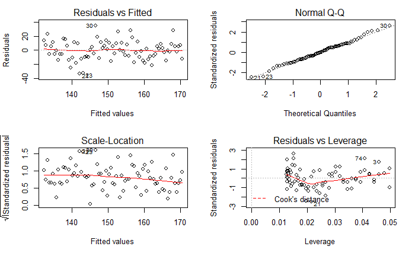

```r
oldpar <- par(mfrow=c(2,2))
plot(ffdays.lm)
par(oldpar)
```

Theoretically, we know we are dealing with count data, so perhaps something other than a Gaussian model (Poisson or quasi-Poisson GLM?) would perform better, but we don’t see any strong deviations (here) from normality. That’s not unreasonable since the binomial distribution for high counts converges on a normal distribution.

```r
ffdays.lm2 <- lm(frostfree~ year + I(year*year), data = frosts)
anova(ffdays.lm, ffdays.lm2)
```

```
Analysis of Variance Table

Model 1: frostfree ~ year
Model 2: frostfree ~ year + I(year * year)
  Res.Df   RSS Df Sum of Sq      F Pr(>F)
1     77 13802
2     76 13758  1    43.962 0.2429 0.6236
```

```r
firstfrosts.lm <- lm(doy.first ~ year, data = frosts)
summary(firstfrosts.lm)
```

```
Call:
lm(formula = doy.first ~ year, data = frosts)

Residuals:
     Min       1Q   Median       3Q      Max
-16.2453  -6.3262  -0.1629   5.1501  18.8830

Coefficients:
              Estimate Std. Error t value Pr(>|t|)
(Intercept) -299.16894   79.97312  -3.741 0.000351 ***
year           0.29160    0.04039   7.220 3.18e-10 ***
---
Signif. codes:  0 ‘***’ 0.001 ‘**’ 0.01 ‘*’ 0.05 ‘.’ 0.1 ‘ ’ 1

Residual standard error: 8.186 on 77 degrees of freedom
Multiple R-squared:  0.4037,    Adjusted R-squared:  0.396
F-statistic: 52.13 on 1 and 77 DF,  p-value: 3.176e-10
```

Slightly more than half of the trend is due to later first frosts, about 23 days.

```r
 round(coef(firstfrosts.lm )[2]*80,2)
```

```
 year
23.33
```

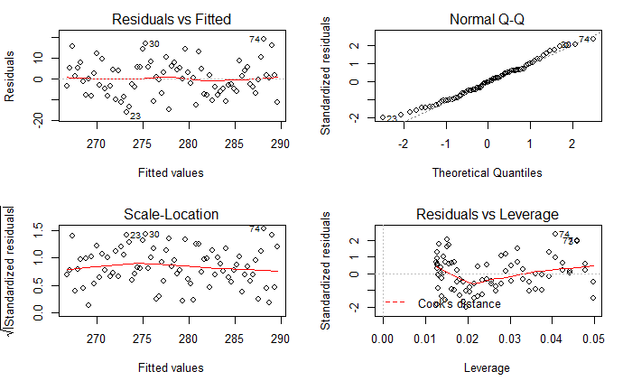

```r
oldpar <- par(mfrow=c(2,2))
plot(firstfrosts.lm)
par(oldpar)
```

## Date of Last Spring Frost

```r
lastfrosts.lm <- lm(doy.last ~ year, data = frosts)
summary(lastfrosts.lm)
```

[output not shown]

So last frosts have moved just over two weeks earlier over eighty years:

```r
round(coef(lastfrosts.lm)[2]*80,2)
```

```
 year
-15.8
```

# Robust alternatives to Gaussian Models

The corresponding Thiel-Sen estimators are similar. Here I am using the ‘mblm’ or “Median Based Linear Models” functions from the mblm package. This fits a Theil-Sen estimator, which is a more robust version of fitting a linear trend. I also run a Kendal’s Tau test, which is (roughly) a test that checks if the Theil-Sen estimator is statistically significant.

```r
ffdays.ts <- mblm(frostfree~ year, dataframe = frosts)
summary(ffdays.ts)
```

```
Call:
mblm(formula = frostfree ~ year, dataframe = frosts)

Residuals:
    Min      1Q  Median      3Q     Max
-32.106  -8.029   1.076  10.327  35.667

Coefficients:
             Estimate       MAD V value Pr(>|V|)
(Intercept) -779.9154  487.3406      69 1.56e-13 ***
year           0.4697    0.2484    3136 2.92e-14 ***
---
Signif. codes:  0 ‘***’ 0.001 ‘**’ 0.01 ‘*’ 0.05 ‘.’ 0.1 ‘ ’ 1

Residual standard error: 13.46 on 77 degrees of freedom
```

```r
cor.test(~frostfree+year, data = frosts, method = 'kendall')
```

```
    Kendall's rank correlation tau

data:  frostfree and year
z = 6.1417, p-value = 8.163e-10
alternative hypothesis: true tau is not equal to 0
sample estimates:
      tau
0.4742577
```

```r
firstfrosts.ts <- mblm(doy.first ~ year, dataframe = frosts)
summary(firstfrosts.ts)
```

```
Call:
mblm(formula = doy.first ~ year, dataframe = frosts)

Residuals:
     Min       1Q   Median       3Q      Max
-22.8047 -11.7332  -5.9793  -0.8999  14.2430

Coefficients:
             Estimate       MAD V value Pr(>|V|)
(Intercept) -218.7350  249.9638     329 9.88e-10 ***
year           0.2540    0.1272    3141 2.42e-14 ***
---
Signif. codes:  0 ‘***’ 0.001 ‘**’ 0.01 ‘*’ 0.05 ‘.’ 0.1 ‘ ’ 1

Residual standard error: 10.18 on 77 degrees of freedom
```

```r
cor.test(~doy.first+year, data = frosts, method = 'kendall')
```

```
    Kendall's rank correlation tau

data:  doy.first and year
z = 5.6313, p-value = 1.789e-08
alternative hypothesis: true tau is not equal to 0
sample estimates:
      tau
0.4364837
```

```r
lastfrosts.ts <- mblm(doy.last ~ year, dataframe = frosts)
summary(lastfrosts.ts)
```

```
Call:
mblm(formula = doy.last ~ year, dataframe = frosts)

Residuals:
     Min       1Q   Median       3Q      Max
-21.7816  -4.7330   0.6569   5.9789  21.7523

Coefficients:
            Estimate      MAD V value Pr(>|V|)
(Intercept) 532.2400 307.0969    3053 6.19e-13 ***
year         -0.2055   0.1482     280 2.14e-10 ***
---
Signif. codes:  0 ‘***’ 0.001 ‘**’ 0.01 ‘*’ 0.05 ‘.’ 0.1 ‘ ’ 1

Residual standard error: 9.702 on 77 degrees of freedom
```

```r
cor.test(~doy.last+year, data = frosts, method = 'kendall')
```

```
    Kendall's rank correlation tau

data:  doy.last and year
z = -3.9164, p-value = 8.988e-05
alternative hypothesis: true tau is not equal to 0
sample estimates:
       tau
-0.3041272
```

# Draft Graphics

Note that as all I fit in this context wer esimple linear models, I can create graphics using geom_smooth() with method =‘lm’. This just draws teh linear model.

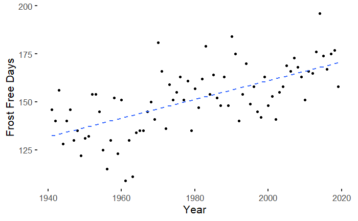

```r
plt <- ggplot(frosts, aes(year, frostfree)) + geom_point() +
  geom_smooth(method = 'lm', se=FALSE, lty=2) +
  ylab('Frost Free Days') +
  xlab('Year') +
  theme_cbep()
plt
```

## Show all three indicators

```r
pltdat <- frosts %>%
  select(-date.first, -date.last) %>%
  gather(key = 'indicator', value = 'days', -year) %>%
  mutate(indicator = factor(indicator,
                            levels = c("frostfree", "doy.first", "doy.last"),
                            labels = c("Frost Free Days", "First Frost", "Last Frost")))
```

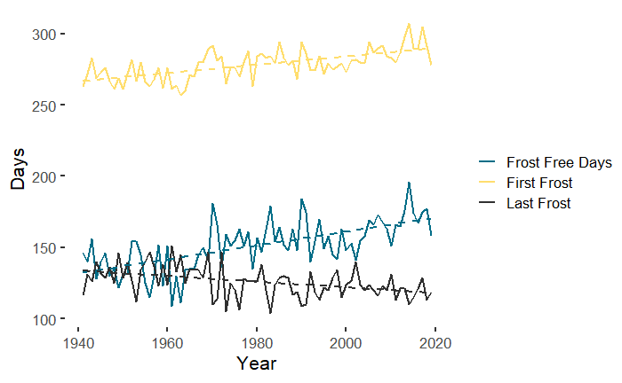

```r
plt <-ggplot(pltdat, aes(year, days, color=indicator)) + geom_line(lwd = 1) +
  geom_smooth(method = 'lm', se = FALSE, lty=2) +
  scale_color_manual(values=cbep_colors, name = '', labels = c('Frost Free Days', 'First Frost', 'Last Frost')) +
  theme_cbep() +
  xlab('Year') +
  ylab('Days')
```

I find that confusing, as the “days” and “Day of Year” are both on the vertical axis, in a confusing way. Lets split

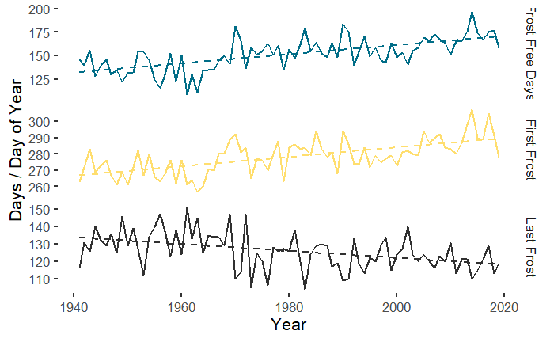

```r
plt +
  theme(legend.position = 'none') +
  facet_wrap('indicator', nrow=3, scales='free_y',
             strip.position = 'right') +
  ylab('Days / Day of Year') +
  scale_color_manual(values=cbep_colors, name = '', labels = c('Frost Free Days', 'First Frost', 'Last Frost')) +
  theme_cbep() +
  theme(panel.spacing = unit(.5, "lines")) +
  theme(legend.position = 'none')
```

# Final Graphic

I don’t like the compound vertical axis. A better solution is to use the strip labels as axis labels, as explained here: https://stackoverflow.com/questions/37573155/showing-different-axis-labels-using-ggplot2-with-facet-wrap

I also increase the size of the graphic slightly, to provide room for the y axis labels.

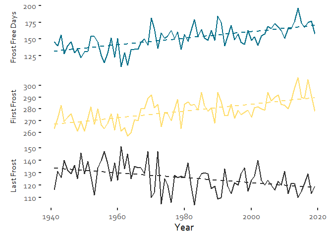

```r
plt1 <- plt +
  ylab(NULL) +
  theme(legend.position = 'none') +
  facet_wrap('indicator', nrow=3, scales='free_y',
             strip.position = 'left') +
  theme(strip.background = element_blank(),
        strip.placement = "outside",
        strip.text = element_text(size = 12),
        panel.spacing = unit(0.5, "lines")) +
    theme(legend.position = 'none')
plt1
```

```r
ggsave('frostfreedaysthreeaxes2.png', width = 7, height = 5, units='in')
```

# 3 And output a PDF version without the Corbel Font

```r
plt2 <- plt1 + theme_cbep(base_family='sans')
ggsave('frostfreedaysthreeaxes2.pdf', plot=plt2,
       device='pdf',
       width = 7, height = 5, units='in')
print(plt2)     # Plot 1 --> in the first page of PDF
dev.off()
```

## Show the first and last frost dates only

```r
tmp <- frosts %>%
  select(-doy.first, -doy.last, -frostfree) %>%
  gather(key = 'indicator', value = 'date', -year) %>%
  mutate(month = format(date, format = '%m')) %>%
  mutate(day = format(date, format = '%d' )) %>%
  mutate(day= ifelse(day=='29' & month == '02', '28', day)) %>%   # Check for unlikely event of leap day
  mutate(compdate = as.Date(paste(month,day,'2019', sep = '/'), format = '%m/%d/%Y'))
```

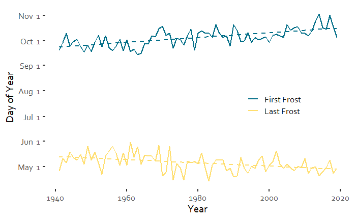

```r
plt <- ggplot(tmp, aes(year, compdate, color=indicator)) + geom_line(lwd = 1) +
  geom_smooth(method = 'lm', se = FALSE, lty=2) +
  scale_color_manual(values = cbep_colors, name = '', labels = c('First Frost', 'Last Frost')) +
  theme_cbep() +
  xlab('Year') +
  ylab('Day of Year')
plt +
  scale_y_date(date_breaks='1 month', date_labels = '%b %e') +
  theme(legend.position=c(0.75,0.5))
```